# BIOS 667 - Lecture 13: GEE Extensions (Ch. 13)

Fitzmaurice, Laird & Ware (2011) - Applied Longitudinal Data Analysis

Naim Rashid

## Lecture Objectives

- Understand **GEE estimation** for binary and count outcomes
- Compare **working correlation** structures and their practical implications
- Distinguish **model-based** vs **robust (sandwich)** standard errors
- Apply **small-sample corrections** for limited cluster sizes
- Perform **GEE diagnostics** and model assessment
- Distinguish **standard GEE** (MCAR) from **IPW-GEE** (MAR) for missing data

## Roadmap

**Day 1 (Parts I-IV):** estimation, working correlation, standard errors, small samples. **Day 2 (Parts V-VIII):** diagnostics, GEE vs mixed, IPW-GEE, applied case study.

| Part | Topic | Day |
| --- | --- | --- |
| I | GEE Review and Estimation | 1 |
| II | Working Correlation Structures | 1 |
| III | Model-Based vs Robust Standard Errors | 1 |
| IV | Small-Sample Corrections | 1 |
| V | GEE Diagnostics and Model Assessment | 2 |
| VI | Comparison with Likelihood Methods | 2 |
| VII | IPW-GEE for MAR Missing Data | 2 |
| VIII | Applied Case Study: Epilepsy Data | 2 |

## Notation reference

| Symbol | Meaning |
| --- | --- |
| $Y_{ij}$ | response for subject $i$ at occasion $j$ (scalar) |
| $\mathbf{Y}_i$ | response vector for subject $i$ $(n_i \times 1)$ |
| $\mathbf{X}_i,\ \boldsymbol\beta$ | fixed-effect design $n_i \times p$ and coefficients |
| $\mathbf{Z}_i,\ \mathbf{b}_i$ | random-effect design and random effects, $\mathbf{b}_i \sim N(0, G)$ |
| $G$ | between-subject random-effects covariance (FLW’s letter, Ch. 8) |
| $R_i$ | within-subject residual covariance, $\boldsymbol\varepsilon_i \sim N(0, R_i)$ |
| $\Sigma_i = \mathbf{Z}_i G \mathbf{Z}_i^\top + R_i$ | marginal (total) covariance $\operatorname{Cov}(\mathbf{Y}_i)$ for subject $i$ |
| $\rho$ | correlation parameter (AR(1), exchangeable) |

Indices: $i$ subject $1,\dots,N$; $j$ occasion/time $1,\dots,n_i$ ($n$ when balanced); $k$ state (transition models); $g$ group. **Bold** = vector or matrix.

## Notation (this lecture): GEE symbols

| Symbol | Meaning |
| --- | --- |
| $V_i = \mathbf{A}_i^{1/2}\operatorname{Corr}_i(\alpha)\,\mathbf{A}_i^{1/2}$ | GEE **working** covariance for subject $i$ (Ch. 12-13 only) |
| $\operatorname{Corr}_i(\alpha)$ | working **correlation** matrix, a function of $\alpha$ (FLW eq for $V_i$) |
| $\alpha$ | working-correlation parameter(s); scalar for exchangeable/AR(1), a vector for unstructured |
| $\mathbf{A}_i = \operatorname{diag}\{\phi\,v(\mu_{ij})\}$ | diagonal of marginal variances $\operatorname{Var}(Y_{ij})=\phi\,v(\mu_{ij})$ ($v$ = GLM variance function, $\phi$ = dispersion; Ch. 11) |
| $\mathbf{D}_i = \partial\boldsymbol\mu_i/\partial\boldsymbol\beta$ | derivative of the mean wrt $\boldsymbol\beta$ ($n_i \times p$), the mean’s sensitivity to $\boldsymbol\beta$ |
| $\phi$ | dispersion (scale) parameter, the same $\phi$ from the Ch. 11 GLM lecture |
| $R_{ij}$ (IPW only) | response/**observation indicator**: $R_{ij}=1$ if $Y_{ij}$ is observed. Distinct from $\operatorname{Corr}_i(\alpha)$ |

## Part I (Day 1): GEE Review and Estimation

## Marginal Models Recap

From Lecture 12, marginal models have three parts:

**Mean:**
$$E(Y_{ij}\mid X_{ij}) = \mu_{ij}, \quad g(\mu_{ij}) = X_{ij} \boldsymbol\beta$$

**Variance:**
$$\operatorname{Var}(Y_{ij}\mid X_{ij}) = \phi \, v(\mu_{ij})$$

**Association:** Working correlation $\operatorname{Corr}_i(\alpha)$ for within-subject dependence

## Why GEE?

| Challenge | GEE Solution |
| --- | --- |
| Full likelihood intractable | Quasi-likelihood |
| Unknown true correlation | Working correlation + robust SEs |
| Binary/count data | No multivariate distribution needed |
| Population-average inference | $\boldsymbol\beta$ interpretation unchanged |

## GEE Estimating Equations

The GEE for $\boldsymbol\beta$ is:

$$U(\boldsymbol\beta) = \sum_{i=1}^{N} \mathbf{D}_i^\top \mathbf{V}_i^{-1}(\mathbf{Y}_i - \boldsymbol\mu_i) = 0$$

where:

- $\mathbf{D}_i = \partial \boldsymbol\mu_i / \partial \boldsymbol\beta$ is the $n_i \times p$ derivative of the mean (its **sensitivity** to $\boldsymbol\beta$)
- $\mathbf{V}_i = \mathbf{A}_i^{1/2} \operatorname{Corr}_i(\alpha)\, \mathbf{A}_i^{1/2}$ is the working covariance (**precision**)
- $\mathbf{A}_i = \operatorname{diag}(\phi\,v(\mu_{ij}))$ contains the marginal variances $\operatorname{Var}(Y_{ij})=\phi\,v(\mu_{ij})$ ($\phi$ = dispersion, the same $\phi$ from Ch. 11)

**In words:** each subject contributes a residual $(\mathbf{Y}_i - \boldsymbol\mu_i)$, weighted by how the mean responds to $\boldsymbol\beta$ ($\mathbf{D}_i$) and down-weighted by its covariance ($\mathbf{V}_i^{-1}$). The sum is set to zero:

$$\underbrace{\mathbf{D}_i^\top}_{\text{sensitivity}}\ \underbrace{\mathbf{V}_i^{-1}}_{\text{precision}}\ \underbrace{(\mathbf{Y}_i - \boldsymbol\mu_i)}_{\text{residual}}$$

## GEE Algorithm (FLW two-stage)

FLW (p. 357) fits GEE by alternating two stages until convergence:

1. Initialize $\hat{\boldsymbol\beta}^{(0)}$ (e.g., from the independence fit)
2. **Given** $\hat\alpha, \hat\phi$: update $\hat{\boldsymbol\beta}$ by solving the estimating equation (iteratively reweighted least squares)
3. **Given** $\hat{\boldsymbol\beta}$: update $\hat\alpha, \hat\phi$ from the standardized residuals $e_{ij}$
4. Iterate steps 2-3 until convergence

**Key insight:** $\hat{\boldsymbol\beta}$ converges to a consistent estimate even if $\operatorname{Corr}_i(\alpha)$ is wrong (so long as the mean model is correct).

## Setup: Load Packages and Data

```r
suppressPackageStartupMessages({
  library(dplyr)
  library(tidyr)
  library(ggplot2)
  library(geepack)
  library(lme4)
  library(broom)
})

# Read epilepsy data
epi_raw <- read.table(
  "../../data/epilepsy.txt",
  skip = 36,
  col.names = c("id", "trt", "age", "base", "y1", "y2", "y3", "y4")
)

# Reshape to long format
epi <- epi_raw |>
  pivot_longer(
    cols = y1:y4,
    names_to = "visit",
    values_to = "seizures"
  ) |>
  mutate(
    visit = as.integer(gsub("y", "", visit)),
    trt = factor(trt, levels = c(0, 1), labels = c("Placebo", "Progabide")),
    log_base = log(base / 4),  # log baseline rate per 2 weeks
    log_age = log(age)
  )

head(epi, 8)
```

## Setup: Load Packages and Data

```
# A tibble: 8 × 8
     id trt       age  base visit seizures log_base log_age
  <int> <fct>   <int> <int> <int>    <int>    <dbl>   <dbl>
1     1 Placebo    31    11     1        5     1.01    3.43
2     1 Placebo    31    11     2        3     1.01    3.43
3     1 Placebo    31    11     3        3     1.01    3.43
4     1 Placebo    31    11     4        3     1.01    3.43
5     2 Placebo    30    11     1        3     1.01    3.40
6     2 Placebo    30    11     2        5     1.01    3.40
7     2 Placebo    30    11     3        3     1.01    3.40
8     2 Placebo    30    11     4        3     1.01    3.40
```

## Epilepsy Trial Data (case study)

Clinical trial of **progabide** for epilepsy:

- 59 patients randomized to treatment or placebo
- Baseline: seizure count in 8-week period before treatment
- Outcome: seizure counts at 4 post-randomization visits (2-week intervals)

**Goal:** Estimate treatment effect on seizure rate (population-average).

**Dataset provenance**

The epilepsy/progabide data are a **Ch. 13 problem dataset** (FLW Problem 13.2, p. 393), including the “exclude patient 49” sensitivity check (Problem 13.2.5). They are a legitimate Ch. 13 example but are not one of the chapter’s three worked Section 13.4 case studies (Muscatine obesity logistic, leprosy bacilli log-linear, arthritis ordinal). We use them as our worked count-data case study.

## Visualize Seizure Trajectories

```r
ggplot(epi, aes(visit, seizures, group = id, color = trt)) +
  geom_line(alpha = 0.3) +
  stat_summary(aes(group = trt), fun = mean, geom = "line",
               linewidth = 1.5) +
  scale_y_log10() +
  labs(
    title = "Seizure Counts Over Time by Treatment",
    x = "Visit (2-week period)",
    y = "Seizure Count (log scale)",
    color = "Treatment"
  ) +
  theme_minimal()
```

## Visualize Seizure Trajectories

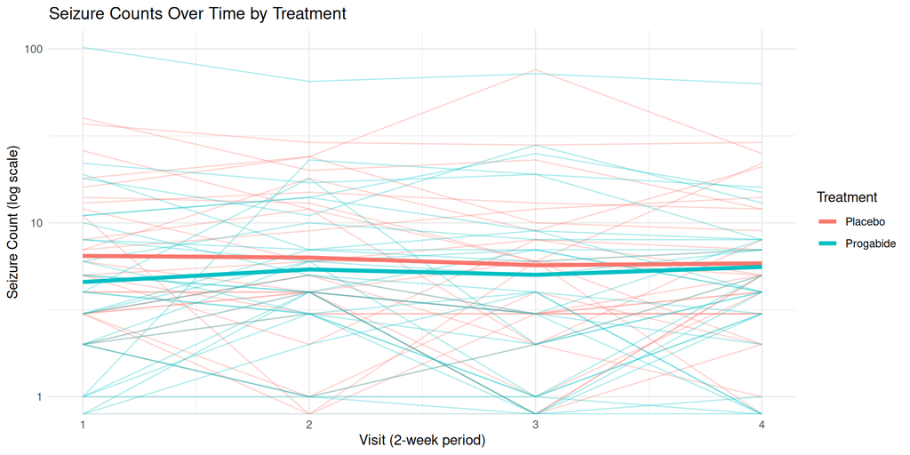

# Part II (Day 1): Working Correlation Structures

## Common Working Correlations

| Structure | $\operatorname{Corr}_{jk}(\alpha)$ | Parameters |
| --- | --- | --- |
| Independence | $I(j=k)$ | 0 |
| Exchangeable | $\alpha$ if $j \neq k$ | 1 |
| AR(1) | $\alpha^{\lvert j-k\rvert}$ | 1 |
| Unstructured | $\alpha_{jk}$ | $n(n-1)/2$ |

## Picture First: Three Correlation Shapes

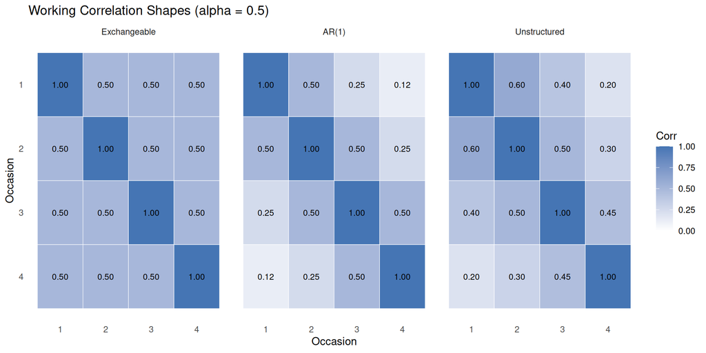

## Exchangeable Correlation

$$\operatorname{Corr}_i(\alpha) = \begin{pmatrix}
1 & \alpha & \alpha & \alpha \\
\alpha & 1 & \alpha & \alpha \\
\alpha & \alpha & 1 & \alpha \\
\alpha & \alpha & \alpha & 1
\end{pmatrix}$$

**Use when:** No natural time ordering; cluster members similar.

## AR(1) Correlation

$$\operatorname{Corr}_i(\alpha) = \begin{pmatrix}
1 & \alpha & \alpha^2 & \alpha^3 \\
\alpha & 1 & \alpha & \alpha^2 \\
\alpha^2 & \alpha & 1 & \alpha \\
\alpha^3 & \alpha^2 & \alpha & 1
\end{pmatrix}$$

**Use when:** Correlation decays with time lag.

## Unstructured Correlation

$$\operatorname{Corr}_i(\alpha) = \begin{pmatrix}
1 & \alpha_{12} & \alpha_{13} & \alpha_{14} \\
\alpha_{12} & 1 & \alpha_{23} & \alpha_{24} \\
\alpha_{13} & \alpha_{23} & 1 & \alpha_{34} \\
\alpha_{14} & \alpha_{24} & \alpha_{34} & 1
\end{pmatrix}$$

**Use when:** Small $n_i$, enough subjects, no assumed pattern.

## GEE with Different Correlations

```r
# Independence
gee_ind <- geeglm(
  seizures ~ trt + log_base + log_age + visit,
  id = id,
  data = epi,
  family = poisson(link = "log"),
  corstr = "independence"
)

# Exchangeable
gee_exch <- geeglm(
  seizures ~ trt + log_base + log_age + visit,
  id = id,
  data = epi,
  family = poisson(link = "log"),
  corstr = "exchangeable"
)

# AR(1)
gee_ar1 <- geeglm(
  seizures ~ trt + log_base + log_age + visit,
  id = id,
  data = epi,
  family = poisson(link = "log"),
  corstr = "ar1"
)

# Unstructured
gee_unstr <- geeglm(
  seizures ~ trt + log_base + log_age + visit,
  id = id,
  data = epi,
  family = poisson(link = "log"),
  corstr = "unstructured"
)
```

## GEE with Different Correlations

## Compare Coefficient Estimates

```r
extract_coefs <- function(fit, name) {
  coef(summary(fit)) |>
    as.data.frame() |>
    tibble::rownames_to_column("term") |>
    mutate(model = name) |>
    select(model, term, Estimate, `Std.err`)
}

bind_rows(
  extract_coefs(gee_ind, "Independence"),
  extract_coefs(gee_exch, "Exchangeable"),
  extract_coefs(gee_ar1, "AR(1)"),
  extract_coefs(gee_unstr, "Unstructured")
) |>
  filter(term == "trtProgabide") |>
  knitr::kable(digits = 4)
```

## Compare Coefficient Estimates

| model | term | Estimate | Std.err |
| --- | --- | --- | --- |
| Independence | trtProgabide | -0.0458 | 0.1868 |
| Exchangeable | trtProgabide | -0.0420 | 0.1869 |
| AR(1) | trtProgabide | -0.0559 | 0.1870 |
| Unstructured | trtProgabide | -0.0538 | 0.1821 |

## Key Observation

Treatment effect estimates are **similar** across working correlations.

**Robust SEs** (default in geepack) protect against misspecification.

**Check Your Understanding: Working Correlations**

1. If you specify exchangeable correlation but the true correlation is AR(1), what happens to your coefficient estimates? What about standard errors?
2. When would you prefer AR(1) over exchangeable correlation?
3. Why is unstructured correlation not always the best choice?

**Answers:**

1. **Coefficient estimates** remain consistent (they converge to the correct population-average values). **Standard errors** may be inefficient (larger than optimal) if you use the model-based SEs. With robust (sandwich) SEs, inference remains valid even if the working correlation is misspecified.
2. Choose AR(1) when observations closer in time are more strongly correlated than distant observations (e.g., disease progression, daily measurements). AR(1) assumes correlation decays exponentially with time lag.
3. Unstructured correlation estimates $n(n-1)/2$ parameters, which can be problematic with: (a) limited subjects (parameters may be poorly estimated), (b) unbalanced data (not all pairs observed), (c) overfitting concerns. Simpler structures (exchangeable, AR(1)) are more efficient when they approximately hold.

## Estimated Working Correlations

```r
cat("Exchangeable alpha:", gee_exch$geese$alpha, "\n")
```

## Estimated Working Correlations

```
Exchangeable alpha: 0.4025429
```

```r
cat("AR(1) alpha:", gee_ar1$geese$alpha, "\n")
```

```
AR(1) alpha: 0.5504609
```

```r
cat("Unstructured alpha:\n")
```

```
Unstructured alpha:
```

```r
print(gee_unstr$geese$alpha)
```

```
alpha.1:2 alpha.1:3 alpha.1:4 alpha.2:3 alpha.2:4 alpha.3:4
0.4582196 0.4058512 0.2512328 0.5813033 0.3022116 0.4205118
```

## Modeling the Association (binary data)

For **binary** outcomes, FLW Ch. 13 treats the within-subject association as something to MODEL, not just a nuisance:

- Correlations are awkward for binary data (bounded by the means)
- Better target: pairwise **odds ratios** $\operatorname{OR}_{jk}$
- **Alternating Logistic Regression (ALR):** a second estimating equation for the association parameters $\alpha$, solved alongside the mean equation for $\boldsymbol\beta$

So $\alpha$ can be a **target of inference** (how does dependence change over time?), not only a working-correlation nuisance.

**Beyond our worked example**

We fit a Poisson (count) case study, so we use a working correlation. The OR/ALR association model is the FLW Ch. 13 extension for binary data (FLW Section 13.4, Muscatine logistic example); R support is in the `geepack` `geese()` / `alr` machinery and the `multgee` package. We flag it here as the defining “extension” of the chapter.

# Part III (Day 1): Model-Based vs Robust Standard Errors

## Two Types of Standard Errors

| Type | Formula | Assumption |
| --- | --- | --- |
| Model-based (naive) | $\mathbf{B}^{-1}$ | Correct $\mathbf{V}_i$ |
| Robust (sandwich) | $\mathbf{B}^{-1} \mathbf{M} \mathbf{B}^{-1}$ | Mean model correct |

**Bread** (sensitivity): $\ \mathbf{B} = \sum_i \mathbf{D}_i^\top \mathbf{V}_i^{-1} \mathbf{D}_i$

**Meat** (observed variability): $\ \mathbf{M} = \sum_i \mathbf{D}_i^\top \mathbf{V}_i^{-1} (\mathbf{Y}_i - \boldsymbol\mu_i)(\mathbf{Y}_i - \boldsymbol\mu_i)^\top \mathbf{V}_i^{-1} \mathbf{D}_i$

**Why is the sandwich robust?**

$\mathbf{M}$ uses the **observed** residual products $(\mathbf{Y}_i - \boldsymbol\mu_i)(\mathbf{Y}_i - \boldsymbol\mu_i)^\top$, so it does not trust the working $\mathbf{V}_i$. If the working correlation is wrong, $\mathbf{M}$ still estimates the true variability. The model-based SE $\mathbf{B}^{-1}$ is correct only if $\mathbf{V}_i$ is correct.

## When to Use Which?

| Scenario | Recommendation |
| --- | --- |
| Large $N$, balanced, replicated covariate patterns | Robust (sandwich) |
| Correlation uncertain, $N$ large | Robust (sandwich) |
| Correlation plausibly correct | Model-based (more efficient) |
| **Small/modest $N$, or severely unbalanced** | **Model-based $\mathbf{B}^{-1}$** (FLW pp. 360-361) |

**Robust is not a blanket default**

The sandwich estimator’s robustness is an **asymptotic** (large-$N$) property. With few independent subjects, or a severely unbalanced design with no replicated covariate patterns, the sandwich is **biased downward and highly variable** (FLW pp. 360-361). FLW’s remedy is to prefer the **model-based estimator $\mathbf{B}^{-1}$** with a plausible working covariance. Robust SEs are the default only when $N$ is large and the design is well-replicated.

## Comparing SE Types in geepack

```r
# Model-based (naive) SEs require fitting with std.err = "jack"
# then extracting the naive variance from the geese object

# Fit model - geepack stores both variance estimates internally
gee_exch_fit <- geeglm(

  seizures ~ trt + log_base + log_age + visit,
  id = id,
  data = epi,
  family = poisson(link = "log"),
  corstr = "exchangeable"
)

# Extract robust (sandwich) SEs - this is the default in summary()
se_robust <- sqrt(diag(gee_exch_fit$geese$vbeta))

# Extract model-based (naive) SEs from vbeta.naiv
# This is (D'V^{-1}D)^{-1}, assuming working covariance is correct
se_naive <- sqrt(diag(gee_exch_fit$geese$vbeta.naiv))

data.frame(
  term = names(coef(gee_exch_fit)),
  SE_robust = round(se_robust, 4),
  SE_model_based = round(se_naive, 4),
  ratio = round(se_robust / se_naive, 2)
)
```

## Comparing SE Types in geepack

```
          term SE_robust SE_model_based ratio
1  (Intercept)    0.9275         1.2339  0.75
2 trtProgabide    0.1869         0.1510  1.24
3     log_base    0.1559         0.1052  1.48
4      log_age    0.2540         0.3335  0.76
5        visit    0.0350         0.0341  1.03
```

## Interpretation of SE Comparison

Read the **ratio** = robust / naive column you just saw:

**Mechanism:** the naive SE believes the working $\mathbf{V}_i$; when $\mathbf{V}_i$ overstates correlation it credits each subject with too little independent information, flipping which SE is bigger.

# Part IV (Day 1): Small-Sample Corrections

## The Small-Sample Problem

Robust SEs rely on an asymptotic (large-$N$) approximation:

$$\hat{\boldsymbol\beta} \ \dot\sim\ N\!\left(\boldsymbol\beta,\ \mathbf{B}^{-1}\mathbf{M}\mathbf{B}^{-1}\right)$$

With few clusters ($N < 40$), the sandwich estimator is **biased downward** (FLW pp. 360-361).

This leads to:

- Underestimated standard errors
- Inflated Type I error rates

**FLW’s own remedy (in-chapter)**

When $N$ is small and a working covariance is plausible, FLW (p. 361) recommends using the **model-based estimator $\mathbf{B}^{-1}$** rather than the sandwich. That is the chapter’s prescription; the named bias corrections on the next slide are beyond FLW Ch. 13.

## Bias-Corrected Sandwich Estimators

**Beyond FLW Ch. 13 (instructor extension)**

These named corrections are not in FLW Ch. 13 (Kauermann & Carroll 2001; Fay & Graubard 2001; Mancl & DeRouen 2001, *Biometrics*). FLW’s in-chapter small-$N$ remedy is the model-based estimator $\mathbf{B}^{-1}$ (p. 361). The corrections below inflate the under-estimated sandwich, differing mainly in aggressiveness.

| Method | Correction |
| --- | --- |
| Kauermann-Carroll (KC) | $(\mathbf{I} - \mathbf{H}_i)^{-1/2}$ adjustment |
| Fay-Graubard (FG) | $(\mathbf{I} - \mathbf{H}_i)^{-1}$ adjustment |
| Mancl-DeRouen (MD) | Delete-one jackknife |

$\mathbf{H}_i$ is the cluster leverage (“hat”) matrix, the cluster analogue of the scalar OLS leverage $h_{ii}$.

## Small-Sample Correction in Practice

```r
# geepack does not implement KC/FG/MD; those live in the geesmv package.
# We illustrate the small-sample idea with a model-agnostic cluster bootstrap.
set.seed(667)
n_boot <- 200
boot_coefs <- matrix(NA, n_boot, 5)

for (b in 1:n_boot) {
  # Resample whole CLUSTERS (subjects) with replacement
  ids <- unique(epi$id)
  boot_ids <- sample(ids, length(ids), replace = TRUE)
  boot_data <- do.call(rbind, lapply(seq_along(boot_ids), function(i) {
    d <- epi[epi$id == boot_ids[i], ]
    d$id <- i   # LOAD-BEARING: GEE needs UNIQUE cluster ids after resampling,
                # or a duplicated subject is merged and the SEs are wrong
    d
  }))

  fit_b <- tryCatch(
    geeglm(
      seizures ~ trt + log_base + log_age + visit,
      id = id,
      data = boot_data,
      family = poisson(link = "log"),
      corstr = "exchangeable"
    ),
    error = function(e) NULL
  )

  if (!is.null(fit_b)) {
    boot_coefs[b, ] <- coef(fit_b)
  }
}

boot_se <- apply(boot_coefs, 2, sd, na.rm = TRUE)
names(boot_se) <- names(coef(gee_exch))

data.frame(
  term = names(boot_se),
  SE_robust = round(se_robust, 4),
  SE_bootstrap = round(boot_se, 4)
)
```

## Small-Sample Correction in Practice

```
                     term SE_robust SE_bootstrap
(Intercept)   (Intercept)    0.9275       1.0868
trtProgabide trtProgabide    0.1869       0.2090
log_base         log_base    0.1559       0.1714
log_age           log_age    0.2540       0.3120
visit               visit    0.0350       0.0341
```

## Degrees of Freedom Adjustments

For small samples, also adjust test statistics:

| Approach | df |
| --- | --- |
| Standard Wald | $\infty$ (normal) |
| Cluster-level | $N - p$ |
| Kenward-Roger-type | Data-dependent |

Use $t_{N-p}$ or $F$ reference distributions instead of $z$ or $\chi^2$.

## Rule of Thumb

| N (clusters) | Recommendation |
| --- | --- |
| $N \geq 40$ | Standard robust SEs adequate |
| $20 \leq N < 40$ | Use bias-corrected SEs |
| $N < 20$ | Consider mixed models or exact methods |

With 59 patients here, standard robust SEs are reasonable.

**Check Your Understanding: Standard Errors and Small Samples**

1. What is the difference between model-based (naive) and robust (sandwich) standard errors?
2. Why do robust SEs tend to be biased downward with few clusters?
3. You have a study with 25 subjects. What precautions should you take for GEE inference?

**Answers:**

1. **Model-based SEs** assume the working covariance structure is correctly specified; they use $(D^\top V^{-1} D)^{-1}$. **Robust SEs** use the sandwich estimator $B^{-1}MB^{-1}$, which uses the observed residuals to estimate the true covariance. Robust SEs are valid even if the working correlation is wrong.
2. The sandwich estimator relies on asymptotic theory (large N). With few clusters, there is not enough information to estimate the “meat” of the sandwich ($M$) well, leading to underestimation of variance. This causes inflated Type I error rates.
3. With 25 subjects (between 20 and 40), use **bias-corrected sandwich estimators** (Kauermann-Carroll, Fay-Graubard, or Mancl-DeRouen). Also consider using $t$ or $F$ distributions with $N-p$ degrees of freedom instead of normal/chi-squared for hypothesis tests.

# Day 1 Recap; Part V (Day 2): Diagnostics

**Recap of Day 1 (Parts I-IV)**

- GEE solves $\sum_i \mathbf{D}_i^\top \mathbf{V}_i^{-1}(\mathbf{Y}_i - \boldsymbol\mu_i) = 0$; $\hat{\boldsymbol\beta}$ is consistent even if $\operatorname{Corr}_i(\alpha)$ is wrong.
- Working correlation affects **efficiency**, not consistency (exchangeable / AR(1) / unstructured).
- **Robust** (sandwich) SE = $\mathbf{B}^{-1}\mathbf{M}\mathbf{B}^{-1}$; **model-based** = $\mathbf{B}^{-1}$. Prefer model-based when $N$ is small or the design is unbalanced.

## Diagnostic Goals for GEE

| Goal | What to Check |
| --- | --- |
| Mean model | Residual patterns |
| Link function | Linearity of predictors |
| Variance function | Scale of residuals |
| Influential clusters | Leverage, deletion |
| Working correlation | QIC comparison |

## Pearson Residuals vs Fitted

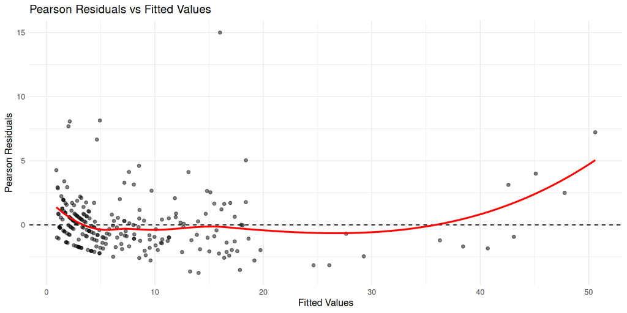

**Reading it**

**Good:** residuals scattered evenly around 0 (dashed line), the red loess roughly flat. **Problematic:** a curved loess (mean-model / link misspecification) or a fan that widens with the fitted value (variance-function misspecification). Here, watch for a few large positive residuals from high-count subjects.

## Residuals by Visit and Treatment

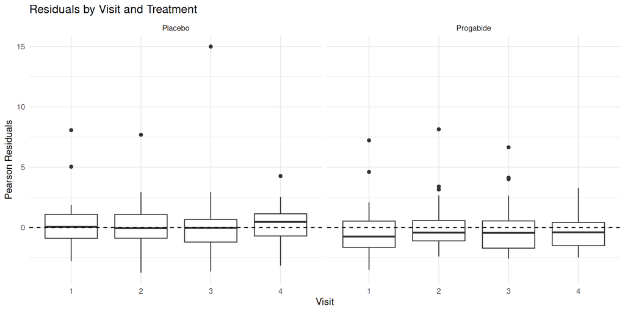

**Reading it**

**Good:** boxes centered on 0 (dashed line) with similar spread across visits and both arms. **Problematic:** a drift in the medians across visits (time trend the mean model missed) or boxes much wider in one arm (heteroscedasticity not captured).

## Cluster-Level Residuals

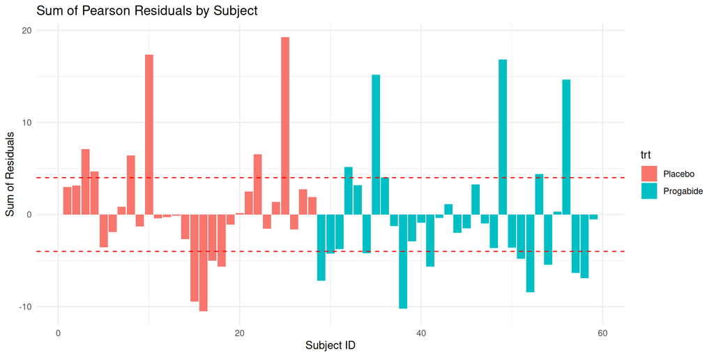

**Reading it**

Each bar sums a subject’s four Pearson residuals. The red dashed lines at $\pm 4$ are an informal flag: bars outside them are subjects the model fits poorly and are candidates for a sensitivity check. **Good:** most bars well inside $\pm 4$. **Problematic:** one or two bars far outside (an influential cluster, e.g. subject 49).

## Identifying Influential Clusters

Subject 49 has extremely high seizure counts:

```r
# Check extreme subjects
epi |>
  group_by(id, trt) |>
  summarize(
    total_seizures = sum(seizures),
    mean_seizures = mean(seizures),
    .groups = "drop"
  ) |>
  arrange(desc(total_seizures)) |>
  head(5)
```

## Identifying Influential Clusters

```
# A tibble: 5 × 4
     id trt       total_seizures mean_seizures
  <int> <fct>              <int>         <dbl>
1    49 Progabide            302          75.5
2    25 Placebo              143          35.8
3    18 Placebo              123          30.8
4     8 Placebo               95          23.8
5    35 Progabide             74          18.5
```

## Sensitivity Analysis: Exclude Outlier

```r
epi_no49 <- epi |> filter(id != 49)

gee_no49 <- geeglm(
  seizures ~ trt + log_base + log_age + visit,
  id = id,
  data = epi_no49,
  family = poisson(link = "log"),
  corstr = "exchangeable"
)

# Compare treatment effects
data.frame(
  model = c("Full data", "Exclude ID 49"),
  trt_coef = c(coef(gee_exch)["trtProgabide"],
               coef(gee_no49)["trtProgabide"]),
  SE = c(summary(gee_exch)$coef["trtProgabide", "Std.err"],
         summary(gee_no49)$coef["trtProgabide", "Std.err"])
) |>
  mutate(
    RR = exp(trt_coef),
    across(c(trt_coef, SE, RR), ~round(.x, 4))
  )
```

## Sensitivity Analysis: Exclude Outlier

```
          model trt_coef     SE     RR
1     Full data   -0.042 0.1869 0.9589
2 Exclude ID 49   -0.262 0.1549 0.7695
```

## Choosing a Working Correlation: FLW’s method

**In-chapter approach (FLW p. 360)**

FLW does NOT pick a working correlation by an information criterion. Its guidance: $\hat{\boldsymbol\beta}$ is consistent under any working assumption, there is often **negligible efficiency loss** from working independence, and you can **compare the empirical (sandwich) SEs across structures**. If the robust SEs are stable across choices, the choice barely matters.

The fitted $\hat\alpha$ values and the robust-vs-naive SE comparison (Part III) are the in-chapter diagnostics. QIC (next slide) is a useful add-on, but it is an instructor extension.

## QIC: Model Selection for GEE

**Beyond FLW Ch. 13 (instructor extension)**

QIC / QICu are due to **Pan (2001), *Biometrics***. They are not in FLW Ch. 13, which selects a working correlation by comparing empirical SEs (p. 360). QIC automates that comparison.

- **QIC** -> compare **correlation structures** (same mean model)
- **QICu** -> compare **mean models** (same correlation); QICu is NOT valid for selecting the correlation structure

One actionable rule: smaller is better; use QIC for correlation, QICu for covariates.

## QIC: Code

```r
# QIC() returns a named vector; index by NAME (positions are
# geepack-version-dependent). "QIC" ranks correlation structures;
# "QICu" ranks mean models (same correlation).
qic_row <- function(fit) {
  q <- geepack::QIC(fit)
  c(QIC = unname(q["QIC"]), QICu = unname(q["QICu"]))
}

data.frame(
  correlation = c("Independence", "Exchangeable", "AR(1)", "Unstructured"),
  rbind(qic_row(gee_ind), qic_row(gee_exch),
        qic_row(gee_ar1), qic_row(gee_unstr))
) |>
  arrange(QIC)
```

## QIC: Code

```
   correlation       QIC      QICu
1 Independence -5879.308 -5898.909
2 Exchangeable -5879.027 -5898.895
3 Unstructured -5878.762 -5898.708
4        AR(1) -5876.994 -5897.955
```

# Part VI (Day 2): Comparison with Likelihood Methods

## GEE vs Mixed Models

| Aspect | GEE | Mixed Models |
| --- | --- | --- |
| Target | Population-average $\boldsymbol\beta$ | Subject-specific $\boldsymbol\beta$ |
| Correlation | Working (misspecification OK) | Model-based |
| Missing data | **Standard GEE: MCAR**; IPW-GEE: MAR | MAR with ML |
| Efficiency | Depends on correlation | Higher if model correct |

**Important:** Standard GEE requires **MCAR** for valid inference. **IPW-GEE** extends validity to **MAR** when the dropout model is correctly specified. (IPW-GEE itself is developed in FLW Ch. 17-18, not Ch. 13; we preview it in Part VII.)

## Coefficient Interpretation: link matters

For an **identity link** (continuous data): GEE and mixed-model $\boldsymbol\beta$ have the **same** interpretation.

For a **nonlinear link**:

- GEE $\boldsymbol\beta$: population-average (marginal) effect
- Mixed $\boldsymbol\beta\mid \mathbf{b}$: subject-specific (conditional) effect

**Attenuation is link-specific (not universal)**

- **Logit link (binary):** the marginal slope IS attenuated toward zero relative to the conditional slope. Approximately $\beta^{\text{marg}} \approx (1 + c_2^2\,\sigma_b^2)^{-1/2}\,\beta^{\text{cond}}$ with $c_2 = 16\sqrt{3}/(15\pi) \approx 0.588$, so the multiplier inside is $c_2^2 \approx 0.346$ (FLW p. 477).
- **Log link (Poisson, our example):** random-intercept SLOPES are **NOT** attenuated. Only the intercept shifts by $\sigma_b^2/2$. Marginal and conditional slope coefficients are **equal**.

## Attenuation: the logistic picture

For a **binary** outcome with a subject random intercept $b_i \sim N(0, \sigma_b^2)$, averaging the individual logistic curves over $b_i$ flattens the population-average curve:

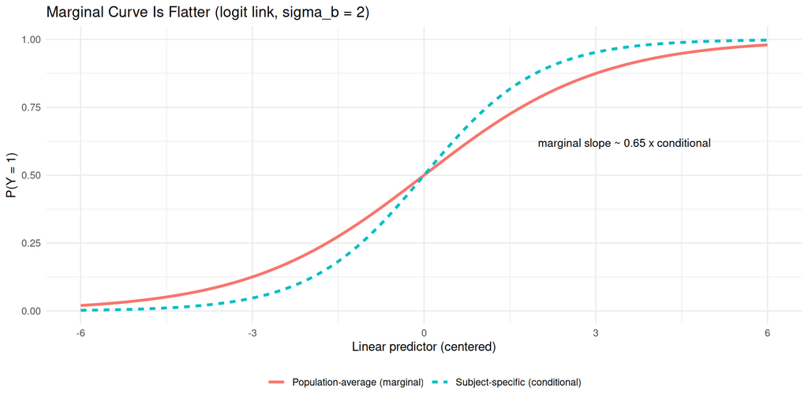

## Mixed Model for Comparison

```r
# GLMM with random intercept
glmm_fit <- glmer(
  seizures ~ trt + log_base + log_age + visit + (1 | id),
  data = epi,
  family = poisson(link = "log")
)

# Compare coefficients
data.frame(
  term = c("(Intercept)", "trtProgabide", "log_base", "log_age", "visit"),
  GEE = round(coef(gee_exch), 4),
  GLMM = round(fixef(glmm_fit), 4)
)
```

## Mixed Model for Comparison

```
                     term     GEE    GLMM
(Intercept)   (Intercept) -1.9860 -0.7316
trtProgabide trtProgabide -0.0420 -0.3232
log_base         log_base  1.2233  1.0211
log_age           log_age  0.5072  0.2608
visit               visit -0.0574 -0.0574
```

## Marginal vs Conditional Effects

```r
# Treatment effect comparison
trt_gee <- coef(gee_exch)["trtProgabide"]
trt_glmm <- fixef(glmm_fit)["trtProgabide"]

data.frame(
  Model = c("GEE (marginal)", "GLMM (conditional)"),
  log_RR = c(trt_gee, trt_glmm),
  RR = exp(c(trt_gee, trt_glmm)),
  Interpretation = c("Population-average", "Subject-specific")
) |>
  mutate(across(c(log_RR, RR), ~round(.x, 4)))
```

## Marginal vs Conditional Effects

```
               Model  log_RR     RR     Interpretation
1     GEE (marginal) -0.0420 0.9589 Population-average
2 GLMM (conditional) -0.3232 0.7238   Subject-specific
```

## When to Choose GEE vs GLMM

| Choose GEE when | Choose GLMM when |
| --- | --- |
| Population-average inference | Subject-specific predictions |
| Robust to correlation misspecification | Modeling individual trajectories |
| MCAR missing data (or MAR with IPW-GEE) | MAR missing data |
| Scientific question is about average | Random effects are of interest |

**Note on missing data:** Standard GEE is only valid under MCAR. If dropout depends on observed data (MAR), use IPW-GEE or likelihood-based methods (GLMM).

# Part VII (Day 2): IPW-GEE for MAR Missing Data

**Beyond FLW Ch. 13 (forward look)**

Ch. 13 notes only that standard GEE needs MCAR and that IPW “is discussed in detail in Chapters 17 and 18” (FLW p. 359). IPW-GEE is developed there (and in **Robins, Rotnitzky & Zhao 1995, *JASA***), not in Ch. 13. This Part is a preview of that later material.

## The Missing Data Problem in GEE

**Standard GEE** assumes **MCAR** (Missing Completely at Random):

- Probability of dropout does not depend on outcomes or covariates
- Example: Random equipment failure, administrative censoring

**Reality:** Dropout often depends on observed data (**MAR**):

- Patients with more seizures may drop out
- Treatment side effects may cause attrition
- This violates MCAR and **biases standard GEE**

## IPW-GEE: The Solution for MAR

**Inverse Probability Weighted GEE** (Robins, Rotnitzky & Zhao, 1995):

1. Model the probability of being observed: $\pi_{ij} = \Pr(R_{ij} = 1 \mid \text{history})$
2. Weight each observation by $w_{ij} = 1/\pi_{ij}$
3. Solve the **weighted** estimating equations

$$U_w(\boldsymbol\beta) = \sum_{i=1}^{N} \mathbf{D}_i^\top \mathbf{W}_i \mathbf{V}_i^{-1}(\mathbf{Y}_i - \boldsymbol\mu_i) = 0$$

where $\mathbf{W}_i = \operatorname{diag}(R_{ij}/\hat\pi_{ij})$.

**Notation: $R_{ij}$ here is the observation indicator**

$R_{ij} = 1$ if $Y_{ij}$ is observed (FLW missing-data notation). This is **distinct** from the working correlation $\operatorname{Corr}_i(\alpha)$ used throughout the deck. Same letter, different object.

## IPW-GEE Validity Conditions

IPW-GEE is **consistent** if:

1. **MAR holds:** dropout depends only on observed data
2. **Monotone dropout:** once a subject leaves, they do not return (FLW’s weight model)
3. **Dropout model correctly specified:** $\pi_{ij}$ estimated consistently
4. **Positivity:** $\pi_{ij} > 0$ for all observations

**FLW’s weight is a cumulative product**

Under monotone MAR dropout FLW uses the **cumulative** stay-in weight
$$w_{ij} = 1 \big/ \textstyle\prod_{k \le j} \Pr(R_{ik}=1 \mid R_{i,k-1}=1, \text{history}),$$
and the proper **IPW sandwich variance** (which accounts for estimating the weights). Our example uses a single-visit $1/\hat\pi_{ij}$ weight, a teaching simplification.

**Trade-off:** IPW-GEE is less efficient than standard GEE when MCAR actually holds.

## IPW-GEE Example: Simulated Dropout

```r
# Create data with MAR dropout
set.seed(667)
epi_mar <- epi |>
  group_by(id) |>
  mutate(
    # Dropout probability depends on previous seizures
    prev_seizures = lag(seizures, default = 0),
    # Higher seizures -> more likely to drop out
    dropout_prob = plogis(-2 + 0.1 * prev_seizures),
    dropout = rbinom(n(), 1, dropout_prob),
    # Cumulative dropout
    ever_dropped = cummax(dropout),
    observed = 1 - ever_dropped
  ) |>
  ungroup()

# Keep only observed data
epi_obs <- epi_mar |> filter(observed == 1)

cat("Original observations:", nrow(epi), "\n")
```

## IPW-GEE Example: Simulated Dropout

```
Original observations: 236
```

```r
cat("Observed after dropout:", nrow(epi_obs), "\n")
```

```
Observed after dropout: 139
```

```r
cat("Dropout rate:", round(1 - nrow(epi_obs)/nrow(epi), 2) * 100, "%\n")
```

```
Dropout rate: 41 %
```

## Fit Dropout Model

```r
# Model probability of being observed given history
dropout_fit <- glm(
  observed ~ trt + log_base + log_age + visit + prev_seizures,
  data = epi_mar,
  family = binomial()
)

# Get predicted probabilities for observed subjects
epi_obs$pi_hat <- predict(dropout_fit, newdata = epi_obs, type = "response")
epi_obs$ipw <- 1 / epi_obs$pi_hat

# Check weight distribution
summary(epi_obs$ipw)
```

## Fit Dropout Model

```
   Min. 1st Qu.  Median    Mean 3rd Qu.    Max.
  1.086   1.144   1.394   1.587   1.815   4.172
```

## Compare Standard GEE vs IPW-GEE

```r
# Standard GEE (ignoring dropout mechanism)
gee_standard <- geeglm(
  seizures ~ trt + log_base + log_age + visit,
  id = id,
  data = epi_obs,
  family = poisson(link = "log"),
  corstr = "exchangeable"
)

# IPW-GEE (accounting for MAR dropout)
gee_ipw <- geeglm(
  seizures ~ trt + log_base + log_age + visit,
  id = id,
  data = epi_obs,
  family = poisson(link = "log"),
  corstr = "exchangeable",
  weights = ipw
)

# Compare treatment effects (save for inline interpretation next slide)
ipw_compare <- data.frame(
  Method = c("Full data (no dropout)", "Standard GEE (MAR ignored)", "IPW-GEE (MAR corrected)"),
  trt_coef = round(c(coef(gee_exch)["trtProgabide"],
                     coef(gee_standard)["trtProgabide"],
                     coef(gee_ipw)["trtProgabide"]), 4),
  SE = round(c(summary(gee_exch)$coef["trtProgabide", "Std.err"],
               summary(gee_standard)$coef["trtProgabide", "Std.err"],
               summary(gee_ipw)$coef["trtProgabide", "Std.err"]), 4)
)
ipw_compare
```

## Compare Standard GEE vs IPW-GEE

```
                      Method trt_coef     SE
1     Full data (no dropout)  -0.0420 0.1869
2 Standard GEE (MAR ignored)  -0.0799 0.2109
3    IPW-GEE (MAR corrected)  -0.1895 0.1906
```

## Interpreting the IPW-GEE Comparison

With the full data, the treatment log-rate-ratio is -0.042. After MAR dropout:

- **Standard GEE** (ignoring dropout) gives -0.08, a distance of 0.038 from the full-data value: dropout has **biased** it.
- **IPW-GEE** gives -0.19, a distance of 0.148 from full-data, not closer to the truth.

**One simulated realization**

## IPW-GEE: Practical Considerations

| Consideration | Recommendation |
| --- | --- |
| **Weight extremes** | Stabilize or truncate weights if $\pi_{ij}$ near 0 |
| **Dropout model** | Include predictors of both dropout AND outcome |
| **Model misspecification** | Use doubly robust methods (AIPW) |
| **Efficiency** | IPW less efficient; use when MAR is plausible |

**Rule of thumb:** If > 10% dropout and mechanism may be MAR, consider IPW-GEE.

## Summary: GEE and Missing Data

| Scenario | Appropriate Method |
| --- | --- |
| Complete data | Standard GEE |
| MCAR dropout | Standard GEE (valid) |
| MAR dropout | **IPW-GEE** or likelihood-based (GLMM) |
| MNAR dropout | Sensitivity analysis, pattern-mixture, selection models |

**Key point:** Standard GEE is only valid under MCAR. For MAR, use IPW-GEE with a correctly specified dropout model.

# Part VIII (Day 2): Applied Case Study Summary

## Full GEE Analysis: Epilepsy Data

```r
# Final model with exchangeable correlation
summary(gee_exch)
```

## Full GEE Analysis: Epilepsy Data

```
Call:
geeglm(formula = seizures ~ trt + log_base + log_age + visit,
    family = poisson(link = "log"), data = epi, id = id, corstr = "exchangeable")

 Coefficients:
             Estimate  Std.err   Wald Pr(>|W|)
(Intercept)  -1.98597  0.92753  4.585   0.0323 *
trtProgabide -0.04197  0.18688  0.050   0.8223
log_base      1.22330  0.15593 61.551 4.33e-15 ***
log_age       0.50719  0.25398  3.988   0.0458 *
visit        -0.05743  0.03498  2.696   0.1006
---
Signif. codes:  0 '***' 0.001 '**' 0.01 '*' 0.05 '.' 0.1 ' ' 1

Correlation structure = exchangeable
Estimated Scale Parameters:

            Estimate Std.err
(Intercept)    4.727   1.163
  Link = identity

Estimated Correlation Parameters:
      Estimate Std.err
alpha   0.4025 0.07227
Number of clusters:   59  Maximum cluster size: 4
```

## Exponentiated Coefficients (Rate Ratios)

```r
coefs <- coef(summary(gee_exch))

# Compute Wald-based 95% CIs manually
estimates <- coefs[, "Estimate"]
se <- coefs[, "Std.err"]
ci_lower <- estimates - 1.96 * se
ci_upper <- estimates + 1.96 * se

results <- data.frame(
  term = rownames(coefs),
  Estimate = estimates,
  SE = se,
  RR = exp(estimates),
  RR_lower = exp(ci_lower),
  RR_upper = exp(ci_upper),
  p_value = coefs[, "Pr(>|W|)"]
)

results |>
  mutate(across(c(Estimate, SE, RR, RR_lower, RR_upper), ~round(.x, 3))) |>
  mutate(p_value = format.pval(p_value, digits = 3))
```

## Exponentiated Coefficients (Rate Ratios)

```
          term Estimate    SE    RR RR_lower RR_upper  p_value
1  (Intercept)   -1.986 0.928 0.137    0.022    0.845   0.0323
2 trtProgabide   -0.042 0.187 0.959    0.665    1.383   0.8223
3     log_base    1.223 0.156 3.398    2.503    4.613 4.33e-15
4      log_age    0.507 0.254 1.661    1.009    2.732   0.0458
5        visit   -0.057 0.035 0.944    0.882    1.011   0.1006
```

## Interpreting Treatment Effect

**Treatment coefficient:** $\hat\beta =$ -0.042

**Rate Ratio:** $\exp(\hat\beta) =$ 0.959

**95% CI:** (0.66, 1.38)

**Interpretation:** On average, progabide patients have about 4.1% lower seizure rates than placebo, but this effect is not statistically significant (p = 0.82).

## Plain-Language Interpretation: GEE Output

| Term | Coefficient | Rate Ratio |
| --- | --- | --- |
| trtProgabide | -0.042 | 0.959 |
| log_base | 1.223 | 3.398 |
| log_age | 0.507 | 1.661 |
| visit | -0.057 | 0.944 |

- **trtProgabide:** rate ratio 0.96, about 4.1% lower (not significant)
- **log_base:** strongest predictor; higher baseline rate -> higher rate throughout
- **visit:** small decline per visit

## Effect of Baseline Seizure Rate

**log_base coefficient:** $\hat\beta =$ 1.223

For each **doubling** of baseline rate:
$$\exp(\hat\beta \times \log 2) = \exp(0.848) = 2.33$$

Patients with higher baseline rates continue to have higher rates on treatment.

## Predicted Rates

```r
# Predictions for average patient
newdata <- expand.grid(
  trt = levels(epi$trt),
  log_base = log(median(epi_raw$base) / 4),
  log_age = log(median(epi_raw$age)),
  visit = 1:4
)

# Use the model matrix to show the linear-predictor mechanics
# (predict(gee_exch, newdata, type = "response") would also work)
X <- model.matrix(~ trt + log_base + log_age + visit, data = newdata)
newdata$pred_rate <- exp(X %*% coef(gee_exch))

ggplot(newdata, aes(visit, pred_rate, color = trt)) +
  geom_line(linewidth = 1.2) +
  geom_point(size = 3) +
  labs(
    title = "Predicted Seizure Rates (Median Patient)",
    x = "Visit",
    y = "Predicted Seizures per 2 Weeks",
    color = "Treatment"
  ) +
  theme_minimal()
```

## Predicted Rates

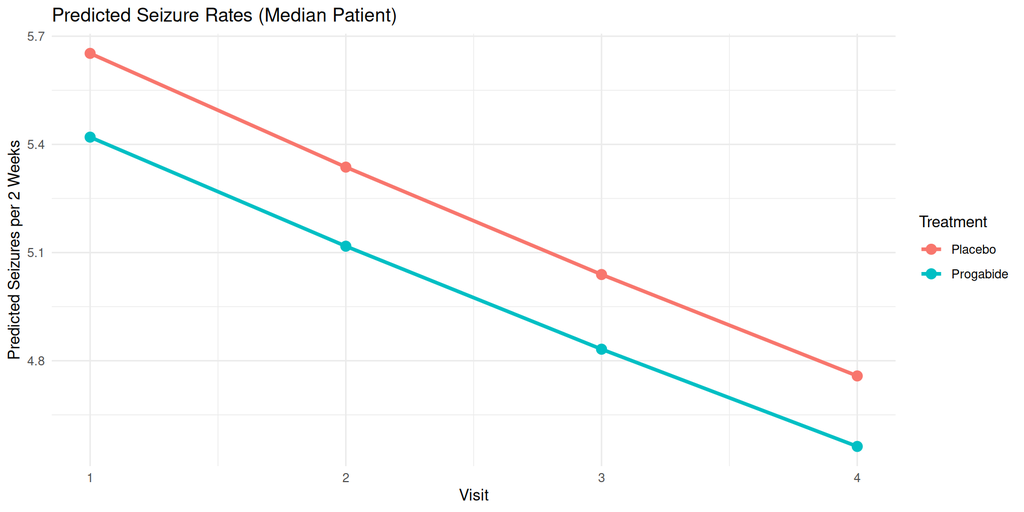

## GEE Extensions: Overdispersion

For count data, we may have overdispersion ($\phi > 1$):

```r
# Estimate dispersion
pearson_stat <- sum(residuals(gee_exch, type = "pearson")^2)
df_resid <- nrow(epi) - length(coef(gee_exch))
phi_hat <- pearson_stat / df_resid

cat("Estimated dispersion:", round(phi_hat, 2), "\n")
```

## GEE Extensions: Overdispersion

```
Estimated dispersion: 4.83
```

```r
cat("Evidence of overdispersion:", ifelse(phi_hat > 1.5, "Yes", "Moderate/No"))
```

```
Evidence of overdispersion: Yes
```

## Handling Overdispersion

Options for overdispersed count data:

1. **Scale parameter:** Multiply variance by $\hat\phi$
2. **Negative binomial:** Different variance function
3. **Robust SEs:** Already account for variance misspecification

GEE with robust SEs handles overdispersion automatically.

## Summary

## Key Takeaways

| Topic | Main Point |
| --- | --- |
| GEE estimation | Consistent $\hat\beta$ even with wrong correlation |
| Working correlation | Affects efficiency, not consistency |
| Robust SEs | Default; protects against misspecification |
| Small samples | Use bias corrections for $N < 40$ |
| Diagnostics | Residuals, QIC/QICu, sensitivity analysis |
| Missing data | **Standard GEE requires MCAR; IPW-GEE valid under MAR** |
| vs. Mixed models | Different interpretations for non-linear links; marginal effects attenuated |

## GEE Checklist for Practice

1. Choose appropriate **link** and **variance** function
2. Select reasonable **working correlation** (start exchangeable/AR1)
3. Always report **robust SEs** (default in geepack)
4. Check **QIC** to compare correlation structures
5. Examine **residuals** and influential clusters
6. Conduct **sensitivity analyses** for outliers
7. Consider **small-sample corrections** if $N < 40$
8. If dropout > 10% and MAR plausible, use **IPW-GEE**

## Common Mistakes in GEE

| Mistake | Why It Is Wrong | Correct Approach |
| --- | --- | --- |
| Using standard GEE with MAR dropout | Standard GEE only valid for MCAR | Use IPW-GEE or likelihood-based methods |
| Ignoring small-sample issues | Sandwich SEs biased downward for N < 40 | Use bias-corrected SEs (KC, FG, MD) |
| Using model-based SEs as default | Only valid if correlation is correct | Report robust (sandwich) SEs |
| Comparing QIC across different mean models | QIC compares correlation structures | Use QICu for mean model comparison |
| Forgetting to check residuals | May miss mean model misspecification | Always examine residual plots |
| Treating GEE $\beta$ as subject-specific | GEE gives population-average effects | Use GLMM for conditional effects |
| Using unstructured correlation with few subjects | Too many parameters to estimate | Use simpler structures (exchangeable, AR1) |

## GEE Recipe Card: A Step-by-Step Workflow

**GEE Analysis in 8 Steps**

**Step 1: Specify the outcome distribution**

- Binary: `family = binomial(link = "logit")`
- Count: `family = poisson(link = "log")`
- Continuous: `family = gaussian(link = "identity")`

**Step 2: Start with a simple working correlation**

- `corstr = "exchangeable"` for general clustering
- `corstr = "ar1"` for time-ordered data

**Step 3: Fit the model**

```r
fit <- geeglm(y ~ x1 + x2 + time, id = subject_id,
              data = mydata, family = ..., corstr = "exchangeable")
```

**Step 4: Check diagnostics**

- Residuals vs fitted
- Residuals by time
- Cluster-level residuals for outliers

**Step 5: Compare correlation structures via QIC**

```r
QIC(fit_exch); QIC(fit_ar1); QIC(fit_unstr)
```

**Step 6: Assess standard errors**

- Always report robust SEs (default in geepack)
- If N < 40, consider bias-corrected SEs or bootstrap

**Step 7: Handle missing data**

- If MCAR: standard GEE is valid
- If MAR: use IPW-GEE with weights

**Step 8: Report results**

- Exponentiate coefficients for OR/RR interpretation
- Include 95% CI from robust SEs
- Note working correlation and QIC

## The Same GEE Fit in SAS

For SAS users, the exchangeable Poisson GEE is `PROC GENMOD` with a `REPEATED` statement (shown for reference, not run):

```sas
proc genmod data=epi;
   class id trt;
   model seizures = trt log_base log_age visit / dist=poisson link=log;
   repeated subject=id / type=exch corrw modelse;
run;
```

- `class id trt;` declares the cluster id and the categorical treatment
- `dist=poisson link=log;` is the marginal Poisson-log mean model
- `repeated subject=id / type=exch` requests the **exchangeable** working correlation (use `type=ar(1)` or `type=un` for the others)
- `corrw` prints the estimated working correlation; `modelse` adds the model-based SEs alongside the default empirical (sandwich) SEs

## For Next Time

- Chapter 14: Transition models
- Modeling dependence on previous outcomes
- Comparison: marginal vs transition interpretations

**Reading:** FLW Chapter 14

## Further Reading

- **FLW Ch. 13** (this chapter): marginal models, GEE, working correlation, sandwich SEs, the Section 13.4 case studies (Muscatine, leprosy, arthritis)
- **FLW Ch. 17-18:** inverse probability weighting and IPW-GEE for MAR dropout (the proper development of Part VII)
- **Liang & Zeger (1986):** the original GEE paper
- **Pan (2001):** QIC for GEE model selection (the Part V extension)

## References

- Fitzmaurice, Laird, Ware (2011). *Applied Longitudinal Analysis*. Ch. 13 (GEE, pp. 354-393); IPW-GEE developed in Ch. 17-18.
- Liang, Zeger (1986). Longitudinal data analysis using generalized linear models. *Biometrika*.
- Pan (2001). Akaike’s information criterion in generalized estimating equations. *Biometrics*. (QIC; beyond Ch. 13)
- Kauermann, Carroll (2001); Fay, Graubard (2001); Mancl, DeRouen (2001). Small-sample sandwich corrections. *JASA / Biometrics*. (beyond Ch. 13)
- Robins, Rotnitzky, Zhao (1995). Semiparametric regression with missing data. *JASA*. (IPW)

## Appendix A: GEE Derivation and Fisher Scoring

The generalized estimating equation:

$$U(\boldsymbol\beta) = \sum_{i=1}^{N} \mathbf{D}_i^\top \mathbf{V}_i^{-1}(\mathbf{Y}_i - \boldsymbol\mu_i) = 0$$

is solved by an iterative update (Fisher scoring, using the expected information):

$$\hat{\boldsymbol\beta}^{(t+1)} = \hat{\boldsymbol\beta}^{(t)} + \left(\sum_i \mathbf{D}_i^\top \mathbf{V}_i^{-1} \mathbf{D}_i\right)^{-1} \sum_i \mathbf{D}_i^\top \mathbf{V}_i^{-1}(\mathbf{Y}_i - \boldsymbol\mu_i^{(t)})$$

**Fisher scoring vs Newton-Raphson:** Fisher scoring uses the *expected* information (model-based, more stable); Newton-Raphson uses the *observed* information (data-based). They coincide for GLMs with a canonical link in the IRLS sense, but that exact equivalence does not carry over to GEE with a non-identity working correlation. The update above is iteratively reweighted least squares with the current weights.

## Appendix B: Sandwich Variance

The robust variance estimator:

$$\widehat{\operatorname{Var}}(\hat{\boldsymbol\beta}) = \mathbf{B}^{-1} \mathbf{M} \mathbf{B}^{-1}$$

where (bread):

$$\mathbf{B} = \sum_i \mathbf{D}_i^\top \mathbf{V}_i^{-1} \mathbf{D}_i$$

and (meat):

$$\mathbf{M} = \sum_i \mathbf{D}_i^\top \mathbf{V}_i^{-1} (\mathbf{Y}_i - \hat{\boldsymbol\mu}_i)(\mathbf{Y}_i - \hat{\boldsymbol\mu}_i)^\top \mathbf{V}_i^{-1} \mathbf{D}_i$$

## Appendix C: QIC Formula (Pan 2001; beyond Ch. 13)

$$\operatorname{QIC}(R) = -2Q(\hat{\boldsymbol\beta}_R; I) + 2\operatorname{trace}(\hat{\boldsymbol\Omega}_I^{-1} \hat{\mathbf{V}}_R)$$

For comparing mean models with the same correlation:

$$\operatorname{QICu} = -2Q(\hat{\boldsymbol\beta}; I) + 2p$$

- $Q(\hat{\boldsymbol\beta}; I)$ is the quasi-likelihood evaluated under the **independence** working model
- $\hat{\boldsymbol\Omega}_I$ is the independence-model (naive) variance
- Smaller QIC indicates a better model